# train8_normal data - New

### Candidate : Kevin Ying

### Classification Test Set #5

### Project task: Binary Classification Challenge

The primary purpose of this project is to make Binary (i.e. 1 or 0) prediction on test set of data with 10k records. The training and Testing set of data include 40k and 10k of records with 100 features respectively. The classifiers for this project are XGB and Random Forest Classifiers. The scope of project includes EDA, Visualization, Modeling and Model determination. The main metrics to measure the performance of the Models are AUC and Recall scores for the highly biased dataset.

### Contents

- I. Import data and Data Cleaning
  - Missing Values
  - Class Distribution
- II. Exploratory Data Analysis (EDA) and Visualization
- III. Correlation plot
- IV. Data Transformation
- IV. Modeling and Forecasting
- V. Model comparision (t_test)
- Final model determination
- Forecast performance discussion and visualization

### Modeling Summary

- The best tuned model is XGB Classifier with 1500 estimators and learning rate = 1.0
- The highest AUC score is about 0.98 out of 1.0 generated by the model
- (Result from t-test) The best Recall score is about 0.89 on the validation set of data (i.e. 33% of records of the original dataset)

```python
import pandas as pd
import numpy as np
from collections import Counter
import matplotlib.pyplot as plt
%matplotlib inline

import warnings
warnings.filterwarnings('ignore')
```

### Reading in the dataset into Notebook Environment

```python
df = pd.read_csv("exercise_05_train.csv")
df_test = pd.read_csv("exercise_05_test.csv")
print("Size of Train Set: ",df.shape)
print("Size of Test Set: ",df_test.shape)
```

```
Size of Train Set:  (40000, 101)
Size of Test Set:  (10000, 100)
```

### Checking Missing Values on Train and Test Set

```python
print("Missing Values on Train Set: ",df.isnull().sum().sum())
print("Missing Values on Test Set: ",df_test.isnull().sum().sum())
```

```
Missing Values on Train Set:  806
Missing Values on Test Set:  194
```

### Check the distribution of Target Label : "y"

As shown below, the class label is biased on the Class "0", the proportion of them is about Four to One (i.e. Class 0 : Class1). In this case, we might want to pay more attention to check on how the predictive model react to the least portion Class Label (i.e. Positive Class )

```
{0: 31853, 1: 8147}
```

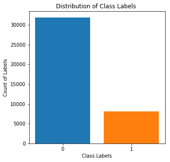

```python
from collections import Counter
c=Counter(df["y"])
c=dict(c)
print(c)

fig=plt.figure(figsize=(5,5))
for label in sorted(list(c.keys())):
    plt.bar(x=str(label),height=c[label])
plt.xticks(ticks=np.arange(0,2)  ,labels=("0","1")  )
plt.title("Distribution of Class Labels ")
plt.xlabel("Class Labels")
plt.ylabel("Count of Labels")
plt.show()
```

### Check data type of columns which are NOT in "float" format

The following step is to check the features which are not in "float" format are taken action to

- 1) De-categorize features (e.g. Convert to float value) for modeling purpose.
- 2) Dummy-out the Categorical features in the binary format (i.e. 1 or 0)

Features:

- x34: Dummy-out x34 feature into Ten binary feature (i.e. 1 or 0)
- x35: Convert x35 feature into Ordinal feature (i.e. Monday -> 1, Tue -> 2 etc)
- x41: Extract the digits including +/- signs from the original string format (e.g. $-865.28 -> 865.28)
- x45: Extract the digits including +/- signs from the original string format (e.g. 0.02% -> 0.02)
- x68: Convert x68 feature into Ordinal feature (i.e. Jan -> 1, Feb -> 2 etc)
- x93: Convert x93 feature into proportion values based on their Categorical value
  - asia -> 0.8846, america -> 0.079175, europe -> 0.03605

```python
print("The following features are not in Float format:")
print()
for col in df.columns:
    if df[col].dtype == "float": pass
    else: print(" - ",col, df[col].dtype)
```

```
The following features are not in Float format:

 -  x34 object
 -  x35 object
 -  x41 object
 -  x45 object
 -  x68 object
 -  x93 object
 -  y int64
```

```python
'''
Extract Numeric Values from Strings (i.e. x41, x45)
'''

df.x41 # Extract digits (exclude "$")
df.x45 # Extract digits (exclude "%")


import re

def extract_digits(item):
    try:
        digits=float(".".join(re.findall("[+-]?\d+",item)))
        #print(digits)
        return (digits)
    except:
        return(item)

#**** Train
lst=[]
for item in df.x41: lst.append(extract_digits(item))
df.x41=lst

lst=[]
for item in df.x45: lst.append(extract_digits(item))
df.x45 = lst



#**** Test
lst=[]
for item in df_test.x41: lst.append(extract_digits(item))
df_test.x41 = lst

lst=[]
for item in df_test.x45: lst.append(extract_digits(item))
df_test.x45 = lst
```

```python
'''
Replace NaN with mode of the column and Dummy out Categorical Variables (i.e. x34)
'''
Counter(df.x34) # Dummy out
Counter(df_test.x34) # Dummy out

# Fill NaN with the MODE value which is "volkswagon"
df.x34= df.x34.fillna(df.x34.value_counts().index[0])
df_test.x34= df_test.x34.fillna(df_test.x34.value_counts().index[0])

#Dummy out "x34" into Binary format
df=pd.get_dummies(df, columns=["x34"], dummy_na=True)
df_test=pd.get_dummies(df_test, columns=["x34"], dummy_na=True)
```

```python
'''
Convert Categorical Variables into Ordinal Variables (i.e. x35, x68)
'''


# Function to Convert Categorical Variables into Ordinal Variables
def cat_to_ord(item):
    try: return("".join(re.findall("[\w+]", item)[:3]).lower()) #ONLY obtain the first letters
    except: return(item)

# **** Train Set
lst=[]
for item in df.x35: lst.append(cat_to_ord(item))
df.x35 = lst
lst=[]
for item in df.x68: lst.append(cat_to_ord(item))
df.x68 = lst


# **** Test Set
lst=[]
for item in df_test.x35: lst.append(cat_to_ord(item))
df_test.x35 = lst
lst=[]
for item in df_test.x68: lst.append(cat_to_ord(item))
df_test.x68 = lst
```

```python
'''
Convert Oridinal into Numerical values
'''

# Ordinal Order for features x35 , x68
ordered_x35 = ["mon","tue","wed","thu","fri", "sat", "sun"]
ordered_x68 = ["jan","feb","mar","apr","may", "jun", "jul", "aug", "sep","oct","nov", "dev"]

# **** Train Set
df.x35 = df.x35.astype("category",ordered=True,categories=ordered_x35).cat.codes
df.x68 = df.x68.astype("category",ordered=True,categories=ordered_x68).cat.codes

# **** Test Set
df_test.x35 = df_test.x35.astype("category",ordered=True,categories=ordered_x35).cat.codes
df_test.x68 = df_test.x68.astype("category",ordered=True,categories=ordered_x68).cat.codes
```

```python
'''
Convert Categorical Variable into Frequency rate (i.e. x93)
'''

#print(Counter(df.x93)) # Convert to Frequency Rate

x = list(Counter(df.x93).values())
asia_rate = x[0]/sum(x)
america_rate = x[1]/sum(x)
europe_rate = x[2]/sum(x)

#print(asia_rate,america_rate, europe_rate)

#Function to convert Categorical variable to Numeric values
def categoical_to_numeric(item):
    try:
        if item.lower() =="asia":
            return(asia_rate)
        elif item.lower() =="america":
            return(america_rate)
        elif item.lower() == 'euorpe':
            return(europe_rate)
    except:
        return(-1)

#**** Train Set
lst=[]
for item in df.x93: lst.append(categoical_to_numeric(item))
df.x93 = lst


#**** Test Set
lst=[]
for item in df_test.x93: lst.append(categoical_to_numeric(item))
df_test.x93 = lst
```

### Display Dataset Property and Statistics

This dataset contains 100 features with with 40000 instances.

- The following shows some information about the features¶
- non_empty_counts: Number of Non-empty Cells of the specific feature
- nulls: Number of Null cells of the specific feature
- pct_nulls: Percent of null cells of the specific feature
- dtype: Type of the feature
- mean: Averge Value of the values of the specific feature
- median: median value of the values of the specific feature
- std: standard deviation of the values of the specific feature
- skewness: skewness of the values of the specific feature
- corr_x_y: Correlation value between the feature and Target Value

Summary:

```python
'''
Function to display Dataset Propety
'''

from scipy.stats import skew
def DisplayT(DF, target_feature):
    counts=DF.count()
    nulls=DF.apply(lambda col: col.isnull().sum())
    pct_nulls = np.round(nulls / DF.shape[0],5)
    means = DF.mean()
    medians = DF.median()
    sds = DF.std()

    skewness = DF.apply(lambda x: skew(x[x.isnull()==False]))

#    uniques=DF.apply(lambda col: [col.unique()])
#    count_uniques = DF.apply(lambda col: len([col.unique()]))
#    count_uniques=[len(lst) for lst in uniques.iloc[0,:].values]

    dtypes=DF.dtypes
    #tbl=pd.DataFrame(list(zip(uniques.iloc[0,:].values)), columns=["uniqueness"])

    tbl=pd.DataFrame(list(zip(DF.columns,
                              counts,
                              nulls,
                              pct_nulls*100 ,
                              dtypes,
                              means,
                              medians,
                              sds,
                              skewness,
                              #uniques.iloc[0,:].values,count_uniques,
                              DF.corr()[target_feature])),
                     columns=["feature","non_empty_counts","nulls","pct_nulls","dtypes",
                              "means",
                              "medians",
                              "sds",
                              "skewness",
                              #"uniqueness", "count_unique",
                              "corr_x_y" ])
    tbl=tbl.set_index("feature")
    tbl=tbl[tbl.index != target_feature]
    return(tbl)
```

```python
with pd.option_context('display.max_rows', None, 'display.max_columns', None):  # more options can be specified also
#    print(df)
    infoDf=DisplayT(df, "y")
    print(infoDf.shape)
#    display(infoDf.sort_values(by="corr_x_y", ascending = False))
#    display(infoDf[infoDf['dtypes']=='float64'].sort_values(by="corr_x_y", ascending = False))
    display(infoDf.sort_values(by="corr_x_y", ascending = False))
```

```
(110, 9)
```

| feature | non_empty_counts | nulls | pct_nulls | dtypes | means | medians | sds | skewness | corr_x_y |
| --- | --- | --- | --- | --- | --- | --- | --- | --- | --- |
| x97 | 39991 | 9 | 0.022 | float64 | -0.562453 | -0.548699 | 4.050658 | 0.031841 | 0.187638 |
| x58 | 39991 | 9 | 0.022 | float64 | -4.254643 | -4.200278 | 30.114887 | -0.008507 | 0.185933 |
| x1 | 39990 | 10 | 0.025 | float64 | -3.924559 | -4.061703 | 18.768656 | 0.040640 | 0.104995 |
| x99 | 39987 | 13 | 0.032 | float64 | 0.179715 | 0.171954 | 4.506750 | 0.010930 | 0.099615 |
| x33 | 39989 | 11 | 0.028 | float64 | -1.008806 | -1.013070 | 5.192007 | -0.016532 | 0.096991 |
| x79 | 39993 | 7 | 0.018 | float64 | 1.274121 | 1.262868 | 25.752753 | -0.023583 | 0.096423 |
| x69 | 39989 | 11 | 0.028 | float64 | -1.662139 | -1.583504 | 15.149470 | 0.000258 | 0.094589 |
| x78 | 39992 | 8 | 0.020 | float64 | -0.996117 | -0.968319 | 5.489479 | 0.019533 | 0.092405 |
| x63 | 39992 | 8 | 0.020 | float64 | -2.519188 | -2.590353 | 13.372699 | 0.013833 | 0.092185 |
| x40 | 39992 | 8 | 0.020 | float64 | 1.129055 | 0.678629 | 21.585912 | 0.091287 | 0.091943 |
| x83 | 39996 | 4 | 0.010 | float64 | 0.759918 | 0.658921 | 16.945744 | -0.015774 | 0.091246 |
| x73 | 39987 | 13 | 0.032 | float64 | -5.706469 | -5.523958 | 30.562153 | -0.047257 | 0.090145 |
| x2 | 39993 | 7 | 0.018 | float64 | 1.006619 | 1.184946 | 21.062970 | -0.022200 | 0.089546 |
| x72 | 39991 | 9 | 0.022 | float64 | -3.011393 | -2.917362 | 15.230049 | -0.036750 | 0.089146 |
| x85 | 39988 | 12 | 0.030 | float64 | -0.565348 | -0.583090 | 2.879633 | 0.015683 | 0.087141 |
| x51 | 39987 | 13 | 0.032 | float64 | -6.839185 | -6.429113 | 39.218449 | -0.047213 | 0.086298 |
| x44 | 39997 | 3 | 0.007 | float64 | -18.847071 | -17.097995 | 76.808795 | -0.174999 | 0.053394 |
| x53 | 39995 | 5 | 0.012 | float64 | 0.013845 | 0.004419 | 3.804674 | 0.012816 | 0.014122 |
| x38 | 39994 | 6 | 0.015 | float64 | 0.007089 | -0.005457 | 2.128168 | 0.008670 | 0.013328 |
| x74 | 39991 | 9 | 0.022 | float64 | 0.355379 | 0.143381 | 36.872256 | 0.036090 | 0.009828 |
| x9 | 39993 | 7 | 0.018 | float64 | -0.017024 | -0.029236 | 1.346529 | 0.015157 | 0.008674 |
| x88 | 39995 | 5 | 0.012 | float64 | 0.014063 | 0.003928 | 3.782974 | 0.007691 | 0.006995 |
| x7 | 39990 | 10 | 0.025 | float64 | -0.025689 | -0.002787 | 5.600785 | -0.011337 | 0.006487 |
| x46 | 39991 | 9 | 0.022 | float64 | 0.016371 | 0.008370 | 5.111123 | -0.011402 | 0.006102 |
| x98 | 39996 | 4 | 0.010 | float64 | 0.000484 | 0.000486 | 0.060034 | -0.008493 | 0.005965 |
| x13 | 39985 | 15 | 0.038 | float64 | 0.000768 | -0.010937 | 1.878066 | -0.004292 | 0.005895 |
| x65 | 39990 | 10 | 0.025 | float64 | -0.017102 | -0.014596 | 3.713853 | 0.003182 | 0.005808 |
| x23 | 39991 | 9 | 0.022 | float64 | -0.003322 | 0.057705 | 7.393135 | -0.012898 | 0.005371 |
| x18 | 39986 | 14 | 0.035 | float64 | 9.541344 | 9.665069 | 38.677783 | -0.022730 | 0.005034 |
| x54 | 39994 | 6 | 0.015 | float64 | -0.029329 | -0.027975 | 5.451172 | -0.007371 | 0.005018 |

[output cut: 80 more lines]

The following chart shows the top correlated features against the Target Variable, e.g. Feature x75 is highly negatively correlated with y.

```
(38, 9)
```

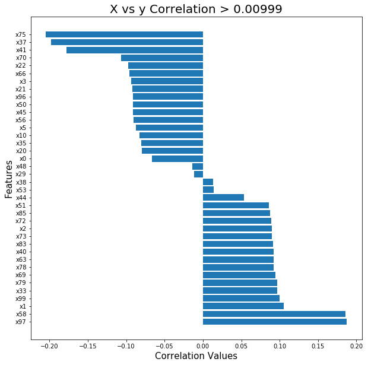

```python
#a=infoDf[infoDf['dtypes']=='float64'][abs(infoDf.corr_x_y) > 0.00999].sort_values(by=["corr_x_y"], ascending=False)
a=infoDf[abs(infoDf.corr_x_y) > 0.00999].sort_values(by=["corr_x_y"], ascending=False)
print(a.shape)
plt.figure(figsize=(10,10))
plt.barh(y= a.index, width=a.corr_x_y)
plt.title("X vs y Correlation > 0.00999", fontsize=20)
plt.ylabel("Features", fontsize=15)
plt.xlabel("Correlation Values", fontsize=15)
plt.show()
```

### Filling in the Missing Values

#### Filling out Missing values with average values for features with -2 < skewness < 2

```python
# **** Train Set *****
df=df.apply(lambda col: col.fillna(col.mean()), axis=0)
print("Missing values in the Train dataset: ",df.isnull().sum().sum())

#Save the Target y on CSV
df["y"].to_csv("y_train.csv", sep=",", index=False)

#Dropping Target variable before saving cleaned dataset
df=df.drop(labels="y", axis=1)
#Save the cleaned dataset to CSV
df.to_csv("cleaned_exercise_05_train.csv", sep=",", index=False)
print("Train Dataset Size", df.shape)
print("Clean Train Dataset Saved!!!")
print()


# **** Test Set *****
df_test=df_test.apply(lambda col: col.fillna(col.mean()), axis=0)
print("Missing values in the Test dataset: ",df_test.isnull().sum().sum())

#Save the cleaned dataset to CSV
df_test.to_csv("cleaned_exercise_05_test.csv", sep=",", index=False)
print("Test Dataset Size", df_test.shape)
print("Clean Test Dataset Saved!!!")
```

```
Missing values in the Train dataset:  0
Train Dataset Size (40000, 110)
Clean Train Dataset Saved!!!

Missing values in the Test dataset:  0
Test Dataset Size (10000, 110)
Clean Test Dataset Saved!!!
```

### Split the Original Dataset into Train and Test Dataset

In this part, the Training set of data is splited into two set for training the models, the proportion of the splited data is 67%(Train set) and 33% (Validation set)

```python
import pandas as pd
import numpy as np
from sklearn.model_selection import train_test_split
'''Read the dataset'''
X = np.array(pd.read_csv("cleaned_exercise_05_train.csv", sep=","))
y = np.array(pd.read_csv("y_train.csv", sep=",", header=None))
y = y.reshape(y.shape[0])

'''Splitting dataset into Train and Test Set'''
X_train, X_test, y_train, y_test = train_test_split(X,
                                                    y,
                                                    test_size=0.33,
                                                    random_state=0)

pd.DataFrame(X_train).to_csv("X_normal_05_train.csv", index=False, header=False )
pd.DataFrame(X_test).to_csv("X_normal_05_test.csv", index=False, header=False )
pd.DataFrame(y_train).to_csv("y_normal_05_train.csv", index=False, header=False )
pd.DataFrame(y_test).to_csv("y_normal_05_test.csv", index=False, header=False )
```

### GridSearch - Processing from Google Cloud

HyperParameters

- XGB
  - n_estimators
  - learning rate
- Random Forest
  - n_estimators
  - criterion

```python
'''
Setting up GridSearch
'''

import pandas as pd
import numpy as np
from scipy import interp
import matplotlib.pyplot as plt
from sklearn.metrics import roc_curve, auc
from sklearn.model_selection import StratifiedKFold
from sklearn.model_selection import cross_validate, GridSearchCV
from sklearn.metrics import recall_score
from xgboost import XGBClassifier
from sklearn.ensemble import RandomForestClassifier


######################################
'''
XGB: Function for GridSearch XGB Classifier and return result Table
'''
def gridXGBCV(clf,X, y, cvFolds, gridParas, scoring):
    gridcv = GridSearchCV(clf,
                          param_grid= gridParas,
                          scoring=scoring,
                          verbose=10,
                          cv=cvFolds,
                          n_jobs =-1)
    gridcv.fit(X,y)
    result=gridcv.cv_results_
    #print(gridcv)


    mean_score_lst = result['mean_test_score']
    n_estimator_lst= [x['n_estimators']for x in result['params']]
    lr_lst = [x['learning_rate']for x in result['params']]


    result=pd.DataFrame(list(zip(mean_score_lst, n_estimator_lst, lr_lst)),
                 columns=["Mean_AUC", "n_estimators", "learning_rate"]).sort_values(by=["Mean_AUC"],
                                                                                    ascending=False)

    return (result)
###########################################
'''
RF: Function for GridSearch Random Forest Classifier and return result Table
'''
def gridRFCV(clf,X, y, cvFolds, gridParas, scoring):
    gridcv = GridSearchCV(clf,
                          param_grid= gridParas,
                          scoring=scoring,
                          verbose=10,
                          cv=cvFolds,
                          n_jobs =-1)
    gridcv.fit(X,y)
    result=gridcv.cv_results_
    print(gridcv)


    mean_score_lst = result['mean_test_score']
    n_estimator_lst= [x['n_estimators']for x in result['params']]
    criterion_lst = [x['criterion']for x in result['params']]


    result=pd.DataFrame(list(zip(mean_score_lst, n_estimator_lst, criterion_lst)),
                 columns=["Mean_AUC", "n_estimators", "criterion"]).sort_values(by=["Mean_AUC"],
                                                                                    ascending=False)

    return (result)


##########################################
```

```python
'''
Call the GridSearch
'''

#Save all the output work in the following directory
dir="data2/"

'''Read the train set'''
X_train=np.array(pd.read_csv(dir + "X_normal_05_train.csv", header=None))
y_train=np.array(pd.read_csv(dir + "y_normal_05_train.csv", header=None))
y_train = y_train.reshape(y_train.shape[0])

print("Train set",X_train.shape, y_train.shape)
#print("Test set",X_test.shape, y_test.shape)


'''Preset Classifier'''
clf = {
"XGB":XGBClassifier(learning_rate=1,n_estimators=2 , random_state=0),
"RF": RandomForestClassifier(n_estimators=2, criterion="gini", max_depth=3)
}


'''Preset Hyperparameters'''
cvFolds=5 #Number of Cross-Validation Fold
#gridParas_xgb = {"n_estimators": [50,100,250,500,800,1000, 1500], "learning_rate":[1,0.1,0.01]} #Hyperparaters for Classifier
gridParas_rf = {"n_estimators": [50,100,250,500,800,1000, 1500], "criterion":["gini", "entropy"]}


scoring = 'roc_auc' #Scoress Measure


'''Call the Function to process GridSearch'''
#result = gridXGBCV(clf["XGB"],X_train, y_train,cvFolds, gridParas_rf, scoring)
result = gridRFCV(clf["RF"],X_train, y_train,cvFolds, gridParas_rf, scoring)
#print(result)

'''Save Result to CSV file'''
dataset_form = "Normal"
name=list(clf.keys())[1]
result.to_csv(dir + "%s_%s"%(dataset_form,name), index=False )

'''Re-read the CSV'''
print(pd.read_csv(dir + "%s_%s"%(dataset_form,name))  )
```

### Modeling 1 - Original Dataset

As shown below, we could observe that the results generated by XGB is superior than the Random Forest Classifiers. The models are trained with the same number of estimators. The best AUC score from R.F. is only about 0.885, however, the best AUC score from XGB which is about 0.985 is 0.1 higher than the R.F. Among the XGB models, the models with learning_rate = 1.0 is out-performed than other models (i.e. lr =0.1 or 0.01). With the XGB models with lr=1, the model generates the highest AUC score under the 5-fold cross validation iteration is the one with n_estimator=1500.

```
Result of Original Dataset - XGB Classifer

    Mean_AUC  n_estimators  learning_rate
0   0.985369          1500           1.00
1   0.985361          1000           1.00
2   0.985269           800           1.00
3   0.984683           500           1.00
4   0.983521          1500           0.10
5   0.981699          1000           0.10
6   0.980540           800           0.10
7   0.979907           250           1.00
8   0.977714           500           0.10
9   0.971028           250           0.10
10  0.968811           100           1.00
11  0.962074          1500           0.01
12  0.958680            50           1.00
13  0.952186          1000           0.01
14  0.951263           100           0.10
15  0.945519           800           0.01
16  0.926335           500           0.01
17  0.924662            50           0.10
18  0.891212           250           0.01
19  0.843864           100           0.01
20  0.816444            50           0.01
```

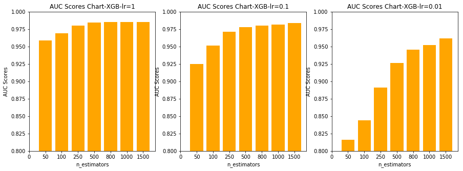

```python
mdf = pd.read_csv("Normal_XGB")
print("Result of Original Dataset - XGB Classifer")
print()
print(mdf)
i=1; plt.figure(figsize=(15,5))
for lr in [1,0.1,0.01]:
    plotDf=mdf[mdf.learning_rate==lr].sort_values(by=["Mean_AUC"])
    plt.subplot(1,3,i)
    plt.bar(x = np.arange(1,8), height=list(plotDf.Mean_AUC), color="Orange")
    plt.xticks(ticks=  np.arange(0,8), labels=[0]+sorted(list(set(mdf.n_estimators))))
    plt.title("AUC Scores Chart-XGB-lr=%s"%str(lr))
    plt.xlabel("n_estimators")
    plt.ylabel("AUC Scores")
    plt.ylim(top=1.0, bottom=0.8)
    i+=1
```

```
Result of Original Dataset - Random Forest Classifer

    Mean_AUC  n_estimators criterion
0   0.885373          1000   entropy
1   0.885193          1500   entropy
2   0.885073           800   entropy
3   0.884128          1500      gini
4   0.883990           250   entropy
5   0.883469           250      gini
6   0.883385          1000      gini
7   0.883329           500   entropy
8   0.882707           800      gini
9   0.882098           500      gini
10  0.878775           100   entropy
11  0.874811           100      gini
12  0.873544            50      gini
13  0.866535            50   entropy
```

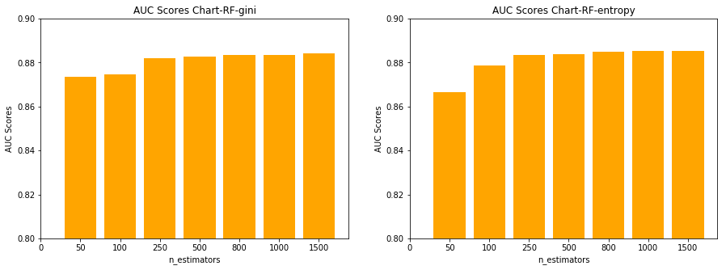

```python
mdf = pd.read_csv("Normal_RF")
print("Result of Original Dataset - Random Forest Classifer")
print()
print(mdf)
i=1; plt.figure(figsize=(15,5))
for md in ["gini", "entropy"]:
    plotDf=mdf[mdf.criterion==md].sort_values(by=["Mean_AUC"])
    plt.subplot(1,2,i)
    plt.bar(x = np.arange(1,8), height=list(plotDf.Mean_AUC), color="Orange")
    plt.xticks(ticks=  np.arange(0,8), labels=[0]+sorted(list(set(mdf.n_estimators))))
    plt.title("AUC Scores Chart-RF-%s"%str(md))
    plt.xlabel("n_estimators")
    plt.ylabel("AUC Scores")
    plt.ylim(top=0.9, bottom=0.8)
    i+=1
```

### Modelling 2 - Principal Components Analysis (PCA(10))

As shown below, we could observe that only the PCA component #1 is already able to explain over 90% of Varience of the dataset. However, the second plot shows there is very hard to differentiate the Class with the first two components. In this case, I would propose not to utilize PCA dataset for modelling at this moment.

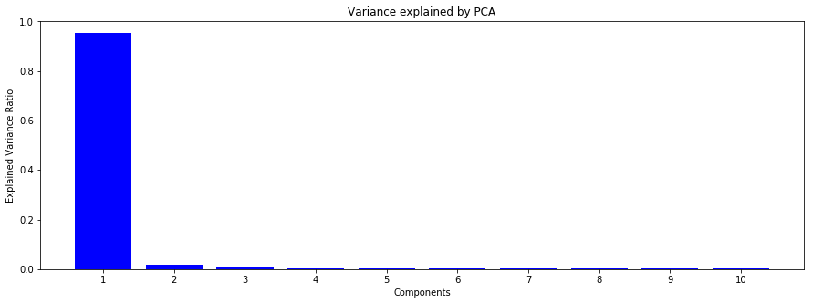

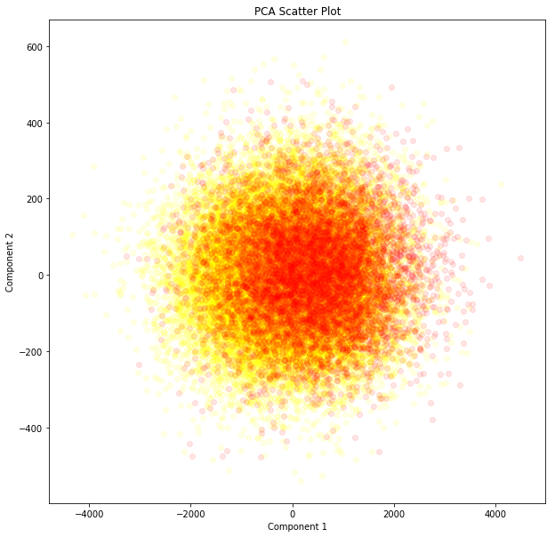

```python
'''Read the dataset'''
X = np.array(pd.read_csv("cleaned_exercise_05_train.csv", sep=","))
y = np.array(pd.read_csv("y_train.csv", sep=",", header=None))
y=y.reshape(y.shape[0])

'''PCA(n=2) for Images Array'''
from sklearn.decomposition import PCA
pca=PCA(n_components=10)
Xpca=pca.fit_transform(X)
plt.figure(figsize =(15,5))
plt.bar(x=np.arange(1,11) ,height =pca.explained_variance_ratio_ , color ="Blue")
plt.title("Variance explained by PCA")
plt.xticks(ticks=np.arange(1,11))
plt.ylabel("Explained Variance Ratio")
plt.xlabel("Components")
plt.show()


plt.figure(figsize=(10,10))
colors=["yellow", "red"]
for color, i in zip(colors, [0, 1]):
    plt.scatter(Xpca[y == i, 0], Xpca[y == i, 1], color=color, alpha=.1)
plt.title("PCA Scatter Plot")
plt.xlabel("Component 1")
plt.ylabel("Component 2")
plt.show()
```

### Modeling 3 - Highly Correlated Features

Based on the following, XGB definitely outperformed than Random Forest Classifiers. The highest AUC score is about 0.98 which is about 0.12 higher than the AUC score generated by R.F classifier. This result is actually similar to the Modeling #1. In this case, I would propose to utilize the Hypothesis t-test to verify which model is actually perform better.

```python
'''
Preparing Dataset which includes only highly correlated features
'''

#Reload the dataset and extract the subset of features with high correlation
X=pd.read_csv("cleaned_exercise_05_train.csv", sep=",")
X=X[list(a.index)] # subset
y = np.array(pd.read_csv("y_train.csv", sep=",", header=None))
y = y.reshape(y.shape[0])
print(X.shape, y.shape)

from sklearn.model_selection import train_test_split

'''Splitting dataset into Train and Test Set'''
X_train, X_test, y_train, y_test = train_test_split(X,
                                                    y,
                                                    test_size=0.33,
                                                    random_state=0)

pd.DataFrame(X_train).to_csv("X_highCorr_05_train.csv", index=False, header=False )
pd.DataFrame(X_test).to_csv("X_highCorr_05_test.csv", index=False, header=False )
pd.DataFrame(y_train).to_csv("y_highCorr_05_train.csv", index=False, header=False )
pd.DataFrame(y_test).to_csv("y_highCorr_05_test.csv", index=False, header=False )
```

```
Result of Subset of Dataset - XGB Classifer

    Mean_AUC  n_estimators  learning_rate
0   0.979824          1500           1.00
1   0.979538          1000           1.00
2   0.979190           800           1.00
3   0.977116           500           1.00
4   0.974856          1500           0.10
5   0.971070          1000           0.10
6   0.969971           250           1.00
7   0.968519           800           0.10
8   0.963600           500           0.10
9   0.958922           100           1.00
10  0.955238           250           0.10
11  0.947035          1500           0.01
12  0.945758            50           1.00
13  0.938792          1000           0.01
14  0.938505           100           0.10
15  0.932884           800           0.01
16  0.915822           500           0.01
17  0.914584            50           0.10
18  0.883344           250           0.01
19  0.839477           100           0.01
20  0.814556            50           0.01
```

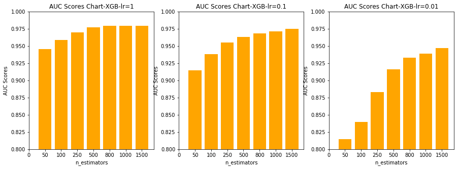

```python
mdf = pd.read_csv("highCorr_XGB")
print("Result of Subset of Dataset - XGB Classifer")
print()
print(mdf)

i=1; plt.figure(figsize=(15,5))
for lr in [1,0.1,0.01]:
    plotDf=mdf[mdf.learning_rate==lr].sort_values(by=["Mean_AUC"])
    plt.subplot(1,3,i)
    plt.bar(x = np.arange(1,8), height=list(plotDf.Mean_AUC), color="Orange")
    plt.xticks(ticks=  np.arange(0,8), labels=[0]+sorted(list(set(mdf.n_estimators))))
    plt.title("AUC Scores Chart-XGB-lr=%s"%str(lr))
    plt.xlabel("n_estimators")
    plt.ylabel("AUC Scores")
    plt.ylim(top=1.0, bottom=0.8)
    i+=1
```

```
Result of Subset of Dataset - Random Forest Classifer

    Mean_AUC  n_estimators criterion
0   0.861731          1500   entropy
1   0.861304           500      gini
2   0.860619           800   entropy
3   0.860613           250   entropy
4   0.860493           500   entropy
5   0.860136           800      gini
6   0.859793           250      gini
7   0.859785          1000   entropy
8   0.858839          1500      gini
9   0.858793          1000      gini
10  0.854603           100      gini
11  0.853075           100   entropy
12  0.850073            50      gini
13  0.848312            50   entropy
```

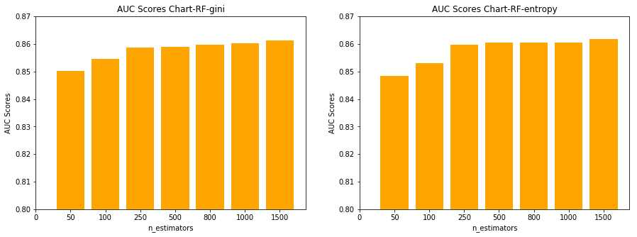

```python
mdf = pd.read_csv("highCorr_RF")
print("Result of Subset of Dataset - Random Forest Classifer")
print()
print(mdf)
i=1; plt.figure(figsize=(15,5))
for md in ["gini", "entropy"]:
    plotDf=mdf[mdf.criterion==md].sort_values(by=["Mean_AUC"])
    plt.subplot(1,2,i)
    plt.bar(x = np.arange(1,8), height=list(plotDf.Mean_AUC), color="Orange")
    plt.xticks(ticks=  np.arange(0,8), labels=[0]+sorted(list(set(mdf.n_estimators))))
    plt.title("AUC Scores Chart-RF-%s"%str(md))
    plt.xlabel("n_estimators")
    plt.ylabel("AUC Scores")
    plt.ylim(top=0.87, bottom=0.8)
    i+=1
```

### Perform t-test to determine the best model

This part is to perform t-test in order to determine the best models from the top two models. The metric we utilize in this part is Recall because we would like to focus small portion Target Class "1"

We first need to set up the Hypothesis as shown below:

- Null: model with original features (Model 1) = model with subset of features (Model 3)
- Alternate: model with original features (Model 1) <> model with subset of features (Model 3)

```python
import pandas as pd
import numpy as np
from xgboost import XGBClassifier
from sklearn.ensemble import RandomForestClassifier
import pickle
from sklearn.metrics import classification_report, recall_score, precision_score, accuracy_score


'''Reload Original Dataset'''
X_train=np.array(pd.read_csv("X_normal_05_train.csv", header=None ))
X_test = np.array(pd.read_csv("X_normal_05_test.csv", header=None ))
y_train = np.array(pd.read_csv("y_normal_05_train.csv", header=None))
y_test = np.array(pd.read_csv("y_normal_05_test.csv", header=None))

#Retrain the model with Original Dataset
clf = XGBClassifier(learning_rate=1,n_estimators=1500 , random_state=0)
clf.fit(X_train, y_train)
pickle.dump(clf, open("model_org_1500", 'wb'))
print("done training")

#Resample 100 times
recall_lst1=[]
for i in range(0,100):
    idx = np.arange(0,X_test.shape[0])
    idx=np.random.choice(idx, int(len(idx)/10))

    X=X_test[idx]
    y=y_test[idx]

    ypred=clf.predict(X)
    recall_lst1.append(recall_score(y, ypred, average=None)[1])
```

```python
X_train = np.array(pd.read_csv("X_highCorr_05_train.csv", header=None ))
X_test = np.array(pd.read_csv("X_highCorr_05_test.csv", header=None ))
y_train = np.array(pd.read_csv("y_highCorr_05_train.csv", header=None ))
y_test = np.array(pd.read_csv("y_highCorr_05_test.csv", header=None ))


#Retrain the model with using the Subset of Dataset
clf = XGBClassifier(learning_rate=1,n_estimators=1500 , random_state=0)
clf.fit(X_train, y_train)
pickle.dump(clf, open("model_highCorr_1500", 'wb'))
print("done training")

#Resample 100 times
recall_lst2=[]
for i in range(0,100):
    idx = np.arange(0,X_test.shape[0])
    idx=np.random.choice(idx, int(len(idx)/10))

    X=X_test[idx]
    y=y_test[idx]

    ypred=clf.predict(X)
    recall_lst2.append(recall_score(y, ypred, average=None)[1])
```

```python
'''t-test to compare model recall'''
from scipy.stats import ttest_ind

# Use scipy.stats.ttest_ind.
t, p = ttest_ind(recall_lst1, recall_lst2, equal_var=False)
print("Model with Original features, Average Recall:", np.mean(recall_lst1))
print("Model with subset high correlated features, Average Recall:", np.mean(recall_lst2))
print("ttest_ind:            t = %g  p = %g" % (t, p))
```

```
Model with Original features, Average Recall: 0.8945523908775721
Model with subset high correlated features, Average Recall: 0.8581790746576382
ttest_ind:            t = 14.0761  p = 1.57699e-31
```

### Feature Importances on the Best Model (XGB Classifier)

The following plots shows the top 40 most relevant features on the best XGB model. The best two features are x72 and x57 respectively which means they make the most influence on the model and outcome from the model.

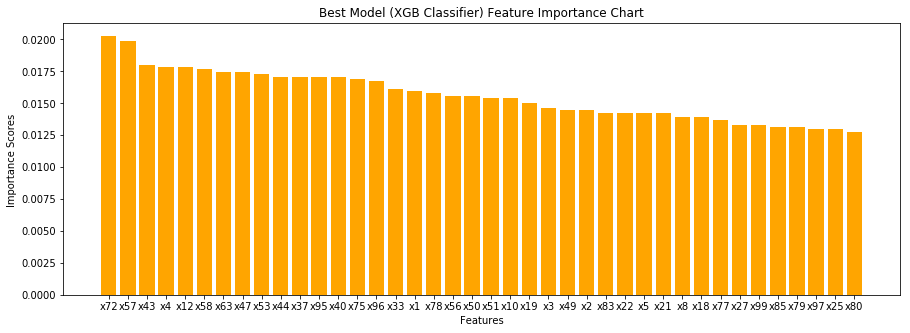

```python
features=pd.read_csv("cleaned_exercise_05_train.csv").columns
loaded_model = pickle.load(open("model_org_1500", 'rb'))
featureDf=pd.DataFrame(list(zip(list(features), list(loaded_model.feature_importances_))),
             columns=["features", "Importances_Score"]).sort_values(by=["Importances_Score"], ascending=False).head(40)
plt.figure(figsize=(15,5))
plt.bar(x=featureDf.features, height= featureDf.Importances_Score, color="orange")
plt.title("Best Model (XGB Classifier) Feature Importance Chart")
plt.ylabel("Importance Scores ")
plt.xlabel("Features")
plt.show()
```

### Make Prediction on Test Set ( i.e. 10000 rows) for Submission

According to the instruction, the predictions are saved to CSV files (i.e. results1.csv, results2.csv) in the class probabilities for belonging to the positive class (labeled '1').

```python
import pickle
Xtest=pd.read_csv("cleaned_exercise_05_test.csv")
loaded_model = pickle.load(open("model_org_1500", 'rb'))
pd.DataFrame(loaded_model.predict_proba(np.array(Xtest))[:,1]).to_csv("results1.csv", header=False, index=False)

loaded_model = pickle.load(open("model_highCorr_1500", 'rb'))
pd.DataFrame(loaded_model.predict_proba(np.array(Xtest[a.index]))[:,1]).to_csv("results2.csv", header=False, index=False)
```

### Summary

The result above shows that the Recall values from the model built by the original features are outperformed the other one. This result actually aligns with the AUC values found in the parts of Modeling #1 and #3, the AUC generated by model with original data is higher thna the model with subset of features. Although the model #1 performs better, but there is disadvantage on that. This model took quite some time to build due to the amount of features is high, Conversely, the model #3 took a lot less time to build due to the dimenision of dataset is reduced. For this reason, I would suggest to take this trade-off into consideration for training purpose.

For this purpose of this exercise, the prediction of test set #1 (i.e. results1.csv) is classified by the best model (i.e. by the Original Dataset). The prediction of test set #2 is classified by the second best model (i.e. by the subset of Dataset).

END!!! Thank you for the review!!!